**산업체 재직자 대상 인공지능 핵심 기초 교육**  
**Class Activation Map (CAM)**

By Prof. Seungchul Lee  
http://iai.postech.ac.kr/  
Industrial AI Lab at POSTECH

Table of Contents

# 1. CNN with a Fully Connected Layer

The conventional CNN can be conceptually divided into two parts. One part is feature extraction and the other is classification. In the feature extraction process, convolution is used to extract the features of the input data so that the classification can be performed well. The classification process classifies which group each input data belongs to by using the extracted features from the input data.

When we visually identify images, we do not look at the whole image; instead, we intuitively focus on the most important parts of the image. CNN learning is similar to the way humans focus. When its weights are optimized, the more important parts are given higher weights. But generally, we are not able to recognize this because the generic CNN goes through a fully connected layer and makes the features extracted by the convolution layer more abstract.

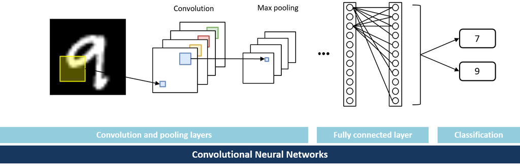

**Issues on CNN (or Deep Learning)**

- Deep learning performs well comparing with any other existing algorithms
- But works as a black box
  - A classification result is simply returned without knowing how the classification results are derived → little interpretability
- When we visually identify images, we do not look at the whole image
- Instead, we intuitively focus on the most important parts of the image
- When CNN weights are optimized, the more important parts are given higher weights
- Class activation map (CAM)
  - We can determine which parts of the image the model is focusing on, based on the learned weights
  - Highlighting the importance of the image region to the prediction

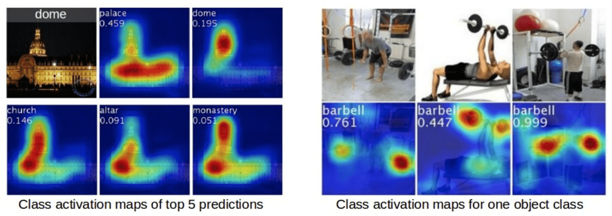

# 2. CAM: CNN with a Global Average Pooling

- shed light on how it explicitly enables the convolutional neural network to have remarkable localization ability
- the heatmap is the class activation map, highlighting the importance of the image region to the prediction

The deep learning model is a black box model. When input data is received, a classification result of 1 or 0 is simply returned for the binary classification problem, without knowing how the classification results are derived. Meanwhile, The class activation map (CAM) is capable of interpreting the results of the classification. We can determine which parts of the image the model is focusing on. Through an analysis of which part of the image the model is focusing on, we are able to interpret which part of the image is considered important.

The class activation map (CAM) is a modified convolution layer. It directly highlights the important parts of the spatial grid of an image. As a result, we can see the emphasized parts of the model. The below figure describes the procedure for class activation mapping.

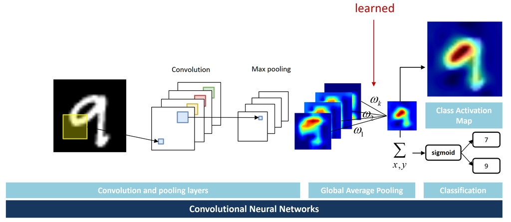

The feature maps of the last convolution layer can be interpreted as a collection of visual spatial locations focused on by the model. The CAM can be obtained by taking a linear sum of the features. They all have different weights and thus can obtain spatial locations according to various input images through a linear combination. For a given image, $f_k(x,y)$ represents the feature map of unit $k$ in the last convolution layer at spatial location $(x,y)$. For a given class $c$, the class score, $S_c$, is expressed as the following equation.

$$S_c = \sum_k \omega_k^c \sum_{x,y} f_k(x,y)= \sum_{x,y} \sum_k \omega_k^c \; f_k(x,y)$$

where $\omega_k^c$ the weight corresponding to class $c$ for unit $k$. The class activation map for class $c$ is denoted as $M_c$.

$$M_c(x,y) = \sum_k \omega_k^c \; f_k(x,y)$$

$M_c$ directly indicates the importance of the feature map at a spatial grid $(x,y)$ of the class $c$. Finally the output of the softmax for class $c$ is,

$$P_c = \frac{\exp\left(S_c\right)}{\sum_c \exp\left(S_c\right)}$$

In case of the CNN, the size of the feature map is reduced by the pooling layer. By simple up-sampling, it is possible to identify attention image regions for each label.

```python
import tensorflow as tf
import matplotlib.pyplot as plt
import numpy as np
from six.moves import cPickle
import cv2
from scipy.signal import spectrogram
import scipy
from sklearn.model_selection import train_test_split
```

[output not shown]

```python
tf.keras.utils.set_random_seed(0)
```

## 2.1. Data Load

```python
# from google.colab import drive
# drive.mount('/content/drive')
```

```python
# laod data

normal = np.load('/content/drive/MyDrive/linc/data_files/normal_split.npy')
inner = np.load('/content/drive/MyDrive/linc/data_files/inner_split.npy')
outer = np.load('/content/drive/MyDrive/linc/data_files/outer_split.npy')
ball = np.load('/content/drive/MyDrive/linc/data_files/ball_split.npy')
```

```python
classes = ['Normal', 'Inner_fault', 'Outer_fault', 'Ball_fault']
data = [normal, inner, outer, ball]
```

```python
x = np.vstack(data)

y = [0]*len(normal) + [1]*len(inner) + [2]*len(outer) + [3]*len(ball)
y = np.array(y)[:, np.newaxis]
```

```python
train_x, test_x, train_y, test_y = train_test_split(x, y, test_size=1/3, random_state=42)
```

```python
Fs = 12000
windowsize = 110
window = np.hanning(windowsize)
nfft = windowsize
noverlap = windowsize/2
```

```python
# Preprocessing
# Transform time domain data to STFT image for all data

train_data_STFT = []
test_data_STFT = []

for i in range(len(train_x)):
    _, _, Sxx = spectrogram(train_x[i],
                            Fs,
                            window = window,
                            noverlap = noverlap,
                            nfft = nfft,
                            scaling = 'spectrum',
                            mode = 'psd')
    train_data_STFT.append(Sxx)

for i in range(len(test_x)):
    _, _, Sxx = spectrogram(test_x[i],
                            Fs,
                            window = window,
                            noverlap = noverlap,
                            nfft = nfft,
                            scaling = 'spectrum',
                            mode = 'psd')
    test_data_STFT.append(Sxx)

train_data_STFT = np.array(train_data_STFT)
test_data_STFT = np.array(test_data_STFT)
```

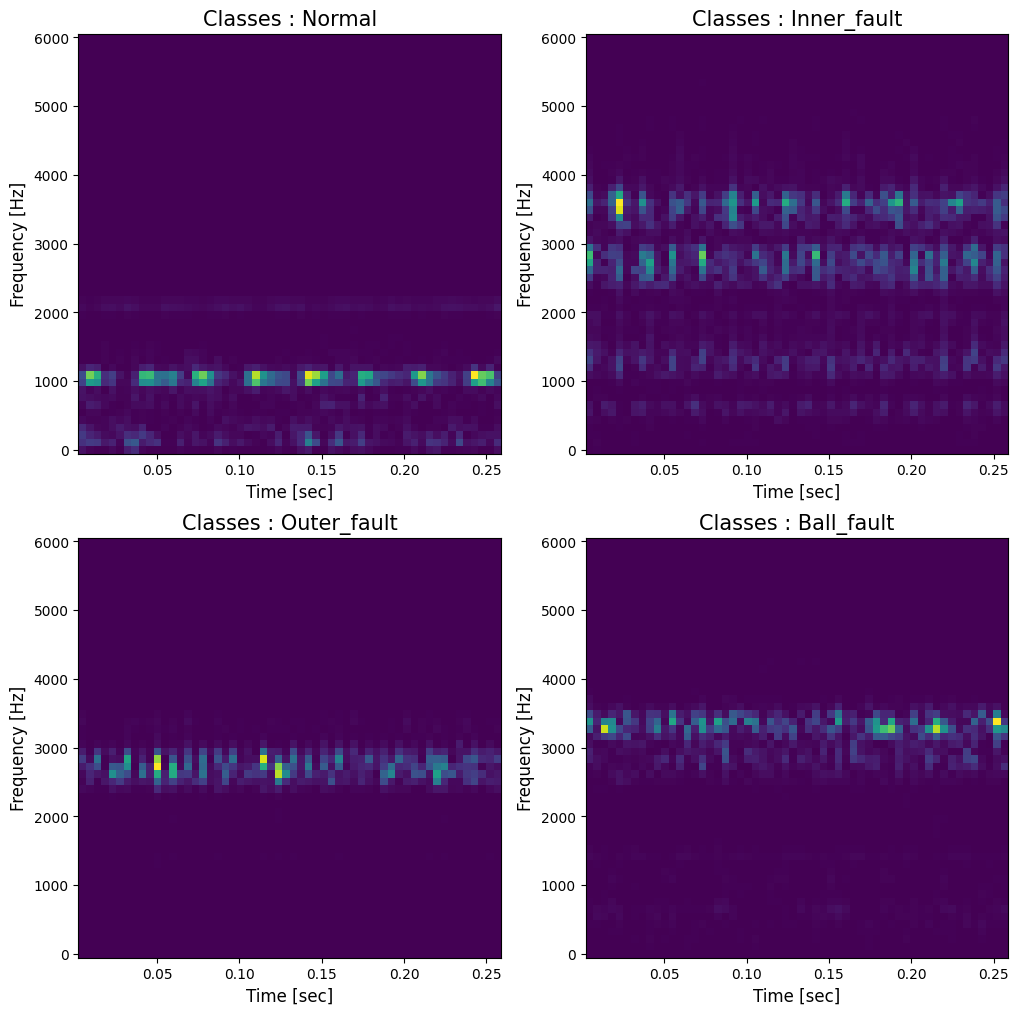

```python
# Show STFT of first data for each class
# Use fs = 12000
#     windowsize = 110

data = [normal, inner, outer, ball]

plt.figure(figsize = (12, 12))

for i in range(4):
    f, t, Sxx = spectrogram(data[i][0],
                            Fs,
                            window = window,
                            noverlap = noverlap,
                            nfft = nfft,
                            scaling = 'spectrum',
                            mode = 'psd')

    plt.subplot(2,2,i+1)
    plt.pcolormesh(t, f, Sxx)
    plt.title('Classes : {}'.format(classes[i]), fontsize = 15)
    plt.ylabel('Frequency [Hz]', fontsize = 12)
    plt.xlabel('Time [sec]', fontsize = 12)
plt.show()
```

## 2.2. Classification Model + GAP

```python
# Define model
# Use 3 layers(convolution + pooling)
#     1 GAP
#     1 Dense layer

model = tf.keras.models.Sequential([
    tf.keras.layers.Conv2D(32,
                           (3,3),
                           activation = 'relu',
                           padding = 'SAME',
                           input_shape = (56, 56, 1)),
    tf.keras.layers.MaxPool2D((2,2)),

    tf.keras.layers.Conv2D(64,
                           (3,3),
                           activation = 'relu',
                           padding = 'SAME'),
    tf.keras.layers.MaxPool2D((2,2)),

    tf.keras.layers.Conv2D(64,
                           (3,3),
                           activation = 'relu',
                           padding = 'SAME'),
    tf.keras.layers.MaxPool2D((2,2)),

    tf.keras.layers.GlobalAveragePooling2D(),
    tf.keras.layers.Dense(4, activation = 'softmax', use_bias = False)
])

model.summary()
```

```
Model: "sequential"
_________________________________________________________________
 Layer (type)                Output Shape              Param #
=================================================================
 conv2d (Conv2D)             (None, 56, 56, 32)        320

 max_pooling2d (MaxPooling2D  (None, 28, 28, 32)       0
 )

 conv2d_1 (Conv2D)           (None, 28, 28, 64)        18496

 max_pooling2d_1 (MaxPooling  (None, 14, 14, 64)       0
 2D)

 conv2d_2 (Conv2D)           (None, 14, 14, 64)        36928

 max_pooling2d_2 (MaxPooling  (None, 7, 7, 64)         0
 2D)

 global_average_pooling2d (G  (None, 64)               0
 lobalAveragePooling2D)

 dense (Dense)               (None, 4)                 256

=================================================================
Total params: 56,000
Trainable params: 56,000
Non-trainable params: 0
_________________________________________________________________
```

[output not shown]

```python
model.compile(optimizer = 'adam',
              loss = 'sparse_categorical_crossentropy',
              metrics = ['accuracy'])
```

```python
# training

model.fit(train_data_STFT, train_y, epochs = 7)
```

```
<keras.callbacks.History at 0x7fca774e5df0>
```

```python
# accuracy test
test_loss, test_acc = model.evaluate(test_data_STFT, test_y)

print('loss = {}, Accuracy = {} %'.format(round(test_loss, 8), round(test_acc*100)))
```

```
loss = 0.14365105, Accuracy = 100 %
```

## 2.3. Class Activatiom Map (CAM)

```python
# get max pooling layer and fully connected layer
conv_layer = model.get_layer(index = 5)
fc_layer = model.get_weights()[6]

# Class activation map
activation_map = tf.matmul(conv_layer.output, fc_layer)
CAM_model = tf.keras.Model(inputs = model.inputs, outputs = activation_map)
```

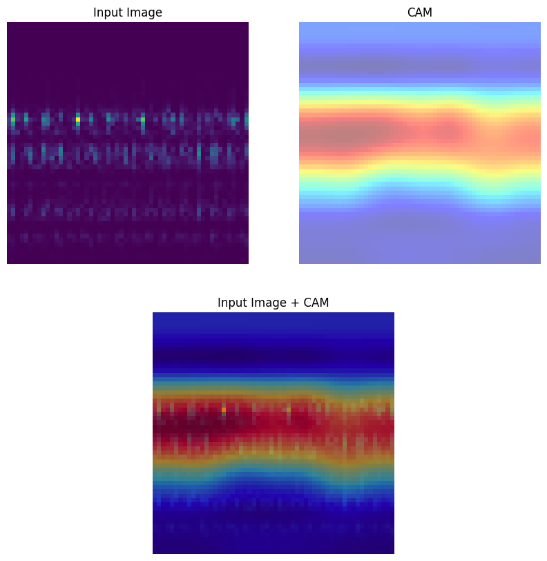

```python
test_img = test_data_STFT[[6]]

pred = np.argmax(model.predict(test_img), axis = 1)

CAM = CAM_model.predict(test_img )
attention = CAM[:,:,:,pred]
attention = np.abs(np.reshape(attention,(7,7)))

test_x = test_img.reshape(56,56)
large_attention = cv2.resize(attention, (56, 56), interpolation = cv2.INTER_CUBIC)

plt.figure(figsize = (10,10))
plt.subplot(2,2,1)
plt.imshow(test_x, origin='lower')
plt.title('Input Image')
plt.axis('off')
plt.subplot(2,2,2)
plt.title('CAM')
plt.imshow(large_attention, 'jet', origin='lower', alpha = 0.5)
plt.axis('off')
plt.subplot(2,1,2)
plt.imshow(test_x)
plt.imshow(large_attention, 'jet', origin='lower', alpha = 0.5)
plt.title('Input Image + CAM')
plt.axis('off')
plt.show()
```

# 3. Semiconductor Wafer Failure Map + CAM

- Wafer failure classification for process analysis in semoconductor fields.

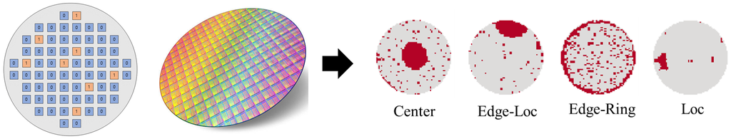

```python
df = cPickle.load(open('/content/drive/MyDrive/linc/data_files/wafers.pkl','rb'))
```

df.head()

- Data distribution

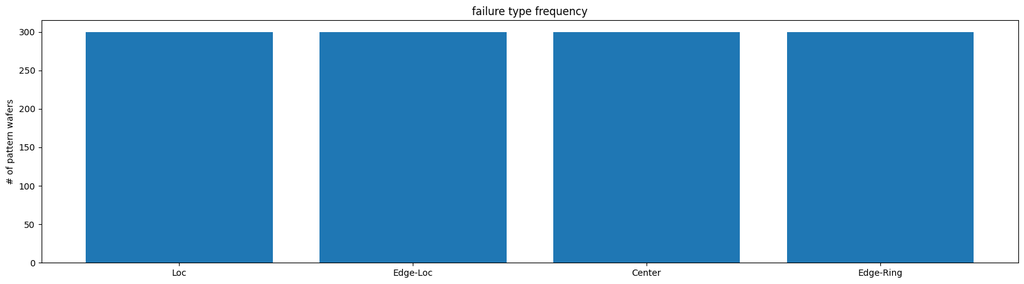

```python
import matplotlib.pyplot as plt
from matplotlib import gridspec

fig = plt.figure(figsize = (20, 5))
uni_pattern=np.unique(df.failureNum, return_counts=True)
labels = ['Loc', 'Edge-Loc', 'Center', 'Edge-Ring']
plt.bar(uni_pattern[0],uni_pattern[1])
plt.title("failure type frequency")
plt.ylabel("# of pattern wafers")
plt.xticks(np.arange(4),labels)
plt.show()
```

- data visualization (size mismatches)

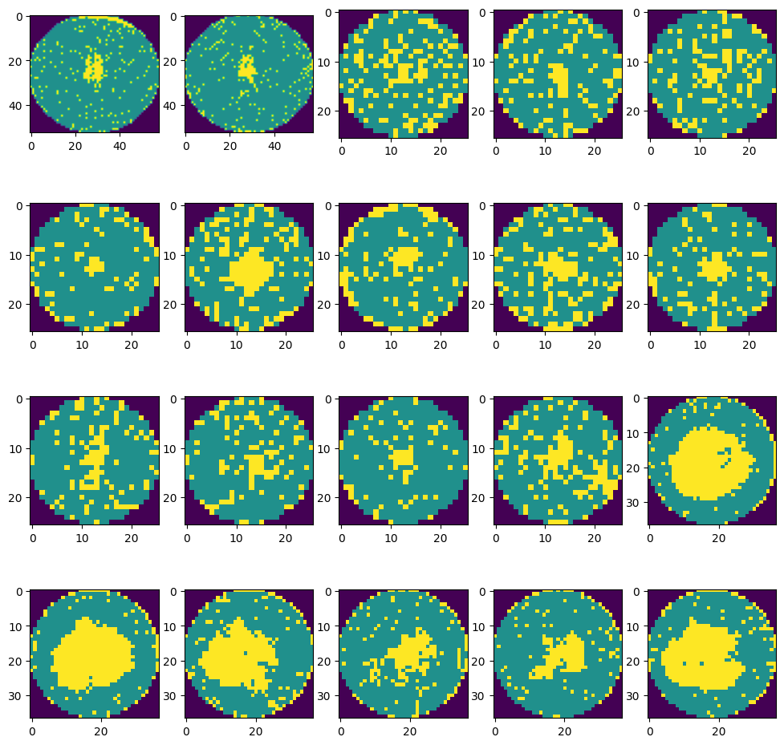

```python
plt.figure(figsize = (12,12))
for i in range(20):
    ax = plt.subplot(4, 5, i+1)
    ax.imshow(df["waferMap"][i])
```

- Different image size $\rightarrow$ image resizing

```python
from PIL import Image

def resizing(img):
    img_tmp = img.copy()
    img_tmp = Image.fromarray(img_tmp)
    img_tmp = img_tmp.resize((32,32))
    img_tmp = np.array(img_tmp)
    return img_tmp
```

```python
df['waferMap_resized'] = df['waferMap'].apply(resizing)
```

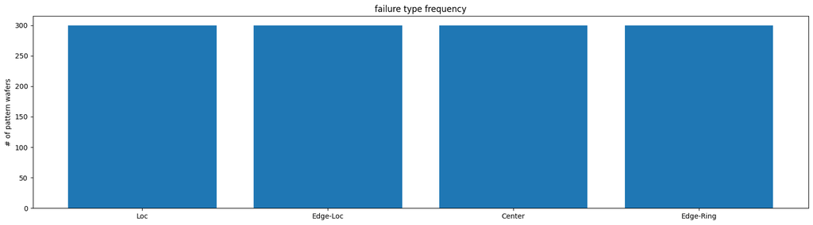

```python
import matplotlib.pyplot as plt
from matplotlib import gridspec

fig = plt.figure(figsize = (20, 5))
uni_pattern=np.unique(df.failureNum, return_counts = True)
labels = ['Loc', 'Edge-Loc', 'Center', 'Edge-Ring']
plt.bar(uni_pattern[0],uni_pattern[1])
plt.title("failure type frequency")
plt.ylabel("# of pattern wafers")
plt.xticks(np.arange(4), labels)
plt.show()
```

Data split: train/test

```python
# split data train, test
tr_idx, te_idx = train_test_split(list(range(1200)), test_size = 0.2, random_state = 2023)
tr_idx, vl_idx = train_test_split(tr_idx, test_size = 0.2, random_state = 2023)

x_train = df['waferMap_resized'][tr_idx].values
y_train = df['encoded_labels'][tr_idx].values

x_valid = df['waferMap_resized'][vl_idx].values
y_valid = df['encoded_labels'][vl_idx].values

x_test = df['waferMap_resized'][te_idx].values
y_test = df['encoded_labels'][te_idx].values
```